# Get started with Kotlin/Wasm in IntelliJ IDEA

This tutorial demonstrates how to use IntelliJ IDEA for creating a Kotlin/Wasm application.

To get started, install the latest version of [IntelliJ IDEA](https://www.jetbrains.com/idea/download/index.html). The tutorial is applicable to both IntelliJ IDEA Community Edition and the Ultimate Edition.

## Enable an experimental Kotlin/Wasm Wizard in IntelliJ IDEA

1. Press double **Shift** to open a search, enter **Registry**.

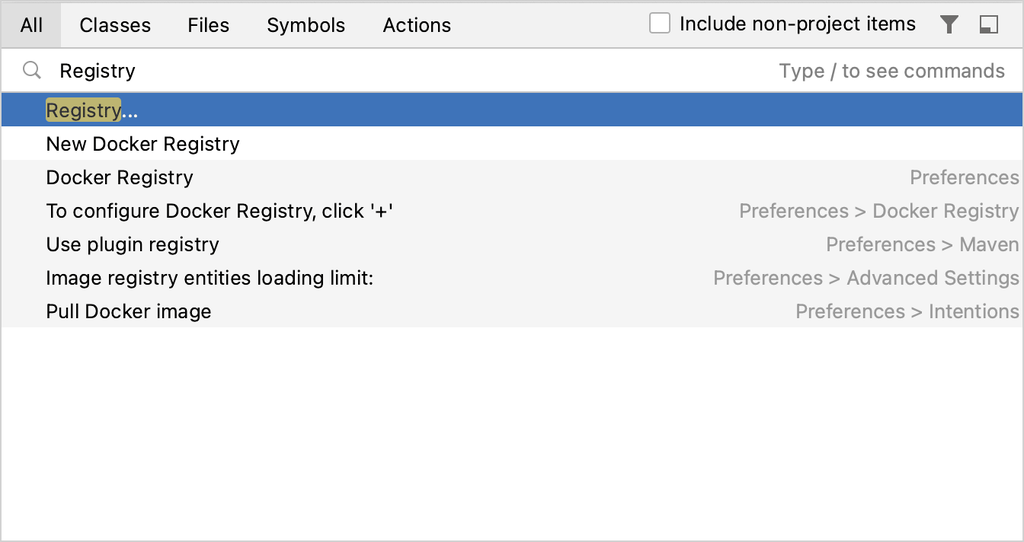

2. Select **Registry** from the list. Registry window opens.
3. Find the `kotlin.wasm.wizard` registry key in the list, and enable it.

[figure not shown]

4. Restart IntelliJ IDEA.

## Create a new Kotlin/Wasm project

1. In IntelliJ IDEA, select **File** | **New** | **Project**.
2. In the panel on the left, select **Kotlin Multiplatform**.
3. Enter a project name, select **Browser Application with Kotlin/Wasm** as the project template, and click **Next**.

[figure not shown]

   By default, your project will use Gradle with Kotlin DSL as the build system.
4. Accept the default configuration on the next screen and click **Finish**. Your project will open.

   By default, the wizard creates the necessary `Simple.kt` file.
5. Open the `build.gradle.kts` file and ensure that the Kotlin Multiplatform plugin version is set to `1.8.20`:

   ```
   plugins {
       kotlin("multiplatform") version "1.8.20"
   }
   ```

## Build and run the application

1. Click **Build Project** next to the run configuration at the top of the screen:

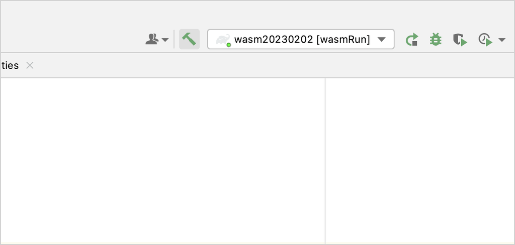

2. Run the application by clicking **Run** next to the run configuration at the top of the screen.
3. Once the application starts, open the following URL in your browser:

   ```
   http://localhost:8080
   ```

   You should see the "JS Client" tab in your browser:

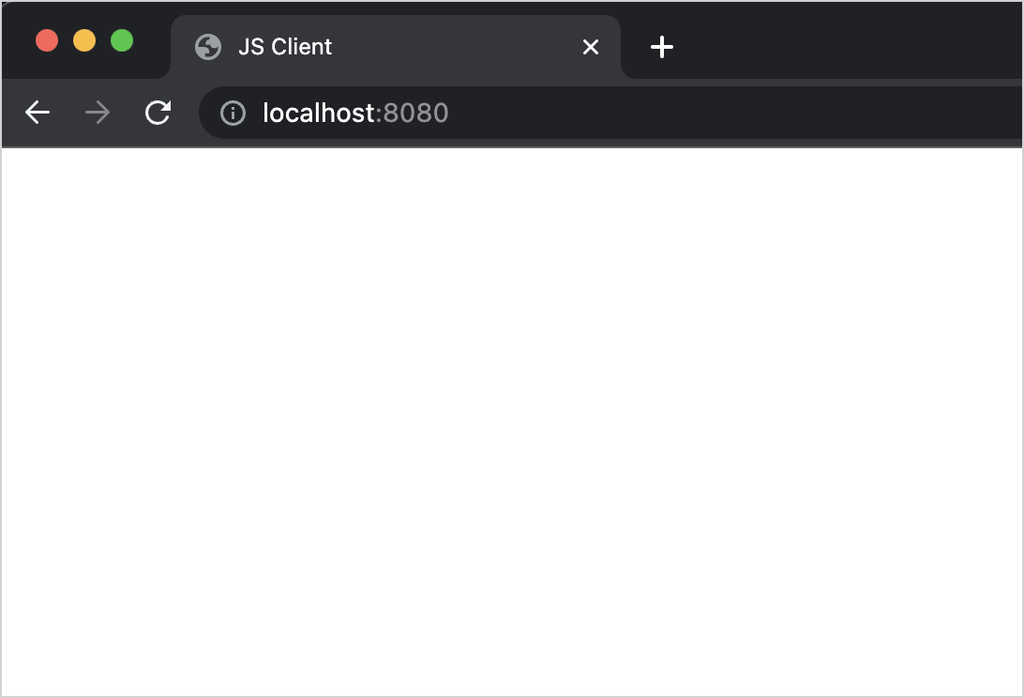

   If you open a page source, you'll find the name of the JavaScript bundle:

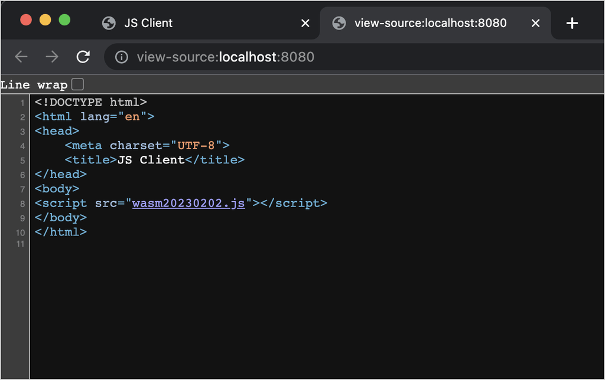

### Troubleshooting

Despite the fact that most of the browsers support WebAssembly, you need to update the settings in your browser.

To run a Kotlin/Wasm project, you need to update the settings of the target environment:

  Run the application with the `--js-flags=--experimental-wasm-gc` command line argument.
- For version 110 or later:
  1. Go to `chrome://flags/#enable-webassembly-garbage-collection` in your browser.
  2. Enable **WebAssembly Garbage Collection**.
  3. Relaunch your browser.

## Update your application

1. Open `Simple.kt` and update the code:

   ```
   import kotlinx.browser.document
   import kotlinx.dom.appendText

   fun main() {
       println("Hello, ${greet()}")
       document.body!!.appendText("Hello, you're using Kotlin/Wasm!")
   }

   fun greet() = "world"
   ```

2. Run the application by clicking **Run** next to the run configuration at the top of the screen.
3. Once the application starts, open the following URL in your browser:

```
http://localhost:8080
```

You'll see the text "Hello, you're using Kotlin/Wasm!":

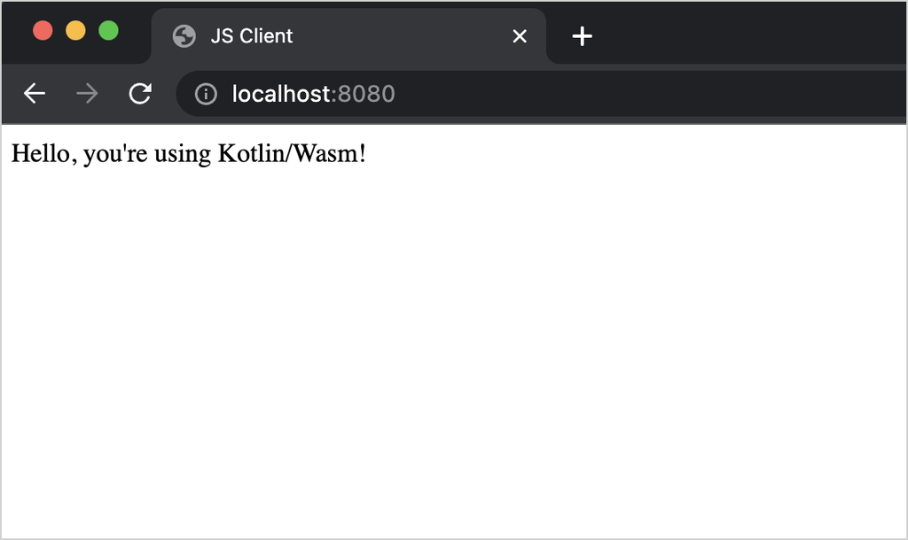

## What's next?

Explore the Kotlin/Wasm interoperability with JavaScript

Last modified: 16 June 2023